# Multi-Class Classification Model for Faulty Steel Plates Using Python Take 2

### November 14, 2019

Template Credit: Adapted from a template made available by Dr. Jason Brownlee of Machine Learning Mastery. [https://machinelearningmastery.com/]

SUMMARY: The purpose of this project is to construct a predictive model using various machine learning algorithms and to document the end-to-end steps using a template. The Faulty Steel Plates dataset is a multi-class classification situation where we are trying to predict one of several (more than two) possible outcomes.

INTRODUCTION: This dataset comes from research by Semeion, Research Center of Sciences of Communication. The original aim of the research was to correctly classify the type of surface defects in stainless steel plates, with six types of possible defects (plus "other"). The Input vector was made up of 27 indicators that approximately the geometric shape of the defect and its outline. According to the research paper, Semeion was commissioned by the Centro Sviluppo Materiali (Italy) for this task and therefore it is not possible to provide details on the nature of the 27 indicators used as Input vectors or the types of the 6 classes of defects.

ANALYSIS: The baseline performance of the machine learning algorithms achieved an average accuracy of 73.99%. Two algorithms (Bagged Decision Trees and Gradient Boosting) achieved the top accuracy metrics after the first round of modeling. After tuning the hyperparameters, Gradient Boosting turned in the top overall result and achieved an accuracy metric of 79.31%. By using the tuned hyperparameters, the Gradient Boosting algorithm processed the testing dataset with an accuracy of 78.80%, which was consistent with the prediction from the training data.

CONCLUSION: For this iteration, the Gradient Boosting algorithm achieved the best overall results using the training and test datasets. For this dataset, Gradient Boosting should be considered for further modeling.

Dataset Used: Steel Plates Faults Data Set

Dataset ML Model: Multi-Class classification with numerical attributes

Dataset Reference: http://archive.ics.uci.edu/ml/datasets/steel+plates+faults

One source of potential performance benchmarks: https://www.kaggle.com/uciml/faulty-steel-plates

The project aims to touch on the following areas:

- Document a predictive modeling problem end-to-end.
- Explore data cleaning and transformation options
- Explore non-ensemble and ensemble algorithms for baseline model performance
- Explore algorithm tuning techniques for improving model performance

Any predictive modeling machine learning project genrally can be broken down into about six major tasks:

1. Prepare Environment
2. Summarize Data
3. Prepare Data
4. Model and Evaluate Algorithms
5. Improve Accuracy or Results
6. Finalize Model and Present Results

## Section 1 - Prepare Environment

### 1.a) Load libraries and modules

```python
# Set the warning message filter
import warnings
warnings.filterwarnings("ignore", category=FutureWarning)
warnings.filterwarnings("ignore", category=DeprecationWarning)
```

```python
# Set the random seed number for reproducible results
seedNum = 888
```

```python
import numpy as np
import pandas as pd
import matplotlib.pyplot as plt
import math
import os
import sys
import shutil
import urllib.request
import zipfile
import smtplib
import re
from datetime import datetime
from email.message import EmailMessage
from pandas.plotting import scatter_matrix
from sklearn import preprocessing
from sklearn.model_selection import train_test_split
from sklearn.model_selection import KFold
from sklearn.model_selection import StratifiedKFold
from sklearn.model_selection import cross_val_score
from sklearn.model_selection import GridSearchCV
from sklearn.metrics import classification_report
from sklearn.metrics import confusion_matrix
from sklearn.metrics import accuracy_score
from sklearn.metrics import roc_auc_score
from sklearn.pipeline import Pipeline
from sklearn.feature_selection import RFE
from imblearn.over_sampling import SMOTE
from imblearn.combine import SMOTEENN
from imblearn.combine import SMOTETomek

from sklearn.discriminant_analysis import LinearDiscriminantAnalysis
from sklearn.tree import DecisionTreeClassifier
from sklearn.neighbors import KNeighborsClassifier
from sklearn.ensemble import BaggingClassifier
from sklearn.ensemble import RandomForestClassifier
from sklearn.ensemble import ExtraTreesClassifier
from sklearn.ensemble import GradientBoostingClassifier
from imblearn.ensemble import BalancedRandomForestClassifier
from imblearn.ensemble import RUSBoostClassifier
from imblearn.ensemble import BalancedBaggingClassifier
from xgboost import XGBClassifier
```

### 1.b) Set up the controlling parameters and functions

```python
# Begin the timer for the script processing
startTimeScript = datetime.now()

# Set up the number of CPU cores available for multi-thread processing
n_jobs = -1

# Set up the flag to stop sending progress emails (setting to True will send status emails!)
notifyStatus = False

# Set the flag for splitting the dataset
splitDataset = True
splitPercentage = 0.25

# Set the number of folds for cross validation
n_folds = 10

# Set various default modeling parameters
scoring = 'accuracy'
```

```python
# Set up the email notification function
def email_notify(msg_text):
    sender = os.environ.get('MAIL_SENDER')
    receiver = os.environ.get('MAIL_RECEIVER')
    gateway = os.environ.get('SMTP_GATEWAY')
    smtpuser = os.environ.get('SMTP_USERNAME')
    password = os.environ.get('SMTP_PASSWORD')
    if sender==None or receiver==None or gateway==None or smtpuser==None or password==None:
        sys.exit("Incomplete email setup info. Script Processing Aborted!!!")
    msg = EmailMessage()
    msg.set_content(msg_text)
    msg['Subject'] = 'Notification from Python Multi-Class Classification Script'
    msg['From'] = sender
    msg['To'] = receiver
    server = smtplib.SMTP(gateway, 587)
    server.starttls()
    server.login(smtpuser, password)
    server.send_message(msg)
    server.quit()
```

```python
if (notifyStatus): email_notify("Library and Data Loading has begun! "+datetime.now().strftime('%a %B %d, %Y %I:%M:%S %p'))
```

### 1.c) Load dataset

```python
colNames = []
variable_path = 'https://archive.ics.uci.edu/ml/machine-learning-databases/00198/Faults27x7_var'
variable_list = urllib.request.urlopen(variable_path)
for line in variable_list:
    item = line.decode("utf-8").rstrip("\r\n")
    colNames = colNames + [item]

dataset_path = 'https://archive.ics.uci.edu/ml/machine-learning-databases/00198/Faults.NNA'
Xy_original = pd.read_csv(dataset_path, names=colNames, sep='\t', header=None)

# Take a peek at the dataframe after import
Xy_original.head(10)
```

|  | X_Minimum | X_Maximum | Y_Minimum | Y_Maximum | Pixels_Areas | X_Perimeter | Y_Perimeter | Sum_of_Luminosity | Minimum_of_Luminosity | Maximum_of_Luminosity | ... | Orientation_Index | Luminosity_Index | SigmoidOfAreas | Pastry | Z_Scratch | K_Scatch | Stains | Dirtiness | Bumps | Other_Faults |
| --- | --- | --- | --- | --- | --- | --- | --- | --- | --- | --- | --- | --- | --- | --- | --- | --- | --- | --- | --- | --- | --- |
| 0 | 42 | 50 | 270900 | 270944 | 267 | 17 | 44 | 24220 | 76 | 108 | ... | 0.8182 | -0.2913 | 0.5822 | 1 | 0 | 0 | 0 | 0 | 0 | 0 |
| 1 | 645 | 651 | 2538079 | 2538108 | 108 | 10 | 30 | 11397 | 84 | 123 | ... | 0.7931 | -0.1756 | 0.2984 | 1 | 0 | 0 | 0 | 0 | 0 | 0 |
| 2 | 829 | 835 | 1553913 | 1553931 | 71 | 8 | 19 | 7972 | 99 | 125 | ... | 0.6667 | -0.1228 | 0.2150 | 1 | 0 | 0 | 0 | 0 | 0 | 0 |
| 3 | 853 | 860 | 369370 | 369415 | 176 | 13 | 45 | 18996 | 99 | 126 | ... | 0.8444 | -0.1568 | 0.5212 | 1 | 0 | 0 | 0 | 0 | 0 | 0 |
| 4 | 1289 | 1306 | 498078 | 498335 | 2409 | 60 | 260 | 246930 | 37 | 126 | ... | 0.9338 | -0.1992 | 1.0000 | 1 | 0 | 0 | 0 | 0 | 0 | 0 |
| 5 | 430 | 441 | 100250 | 100337 | 630 | 20 | 87 | 62357 | 64 | 127 | ... | 0.8736 | -0.2267 | 0.9874 | 1 | 0 | 0 | 0 | 0 | 0 | 0 |
| 6 | 413 | 446 | 138468 | 138883 | 9052 | 230 | 432 | 1481991 | 23 | 199 | ... | 0.9205 | 0.2791 | 1.0000 | 1 | 0 | 0 | 0 | 0 | 0 | 0 |
| 7 | 190 | 200 | 210936 | 210956 | 132 | 11 | 20 | 20007 | 124 | 172 | ... | 0.5000 | 0.1841 | 0.3359 | 1 | 0 | 0 | 0 | 0 | 0 | 0 |
| 8 | 330 | 343 | 429227 | 429253 | 264 | 15 | 26 | 29748 | 53 | 148 | ... | 0.5000 | -0.1197 | 0.5593 | 1 | 0 | 0 | 0 | 0 | 0 | 0 |
| 9 | 74 | 90 | 779144 | 779308 | 1506 | 46 | 167 | 180215 | 53 | 143 | ... | 0.9024 | -0.0651 | 1.0000 | 1 | 0 | 0 | 0 | 0 | 0 | 0 |

10 rows × 34 columns

```python
Xy_original.info()
```

```
<class 'pandas.core.frame.DataFrame'>
RangeIndex: 1941 entries, 0 to 1940
Data columns (total 34 columns):
X_Minimum                1941 non-null int64
X_Maximum                1941 non-null int64
Y_Minimum                1941 non-null int64
Y_Maximum                1941 non-null int64
Pixels_Areas             1941 non-null int64
X_Perimeter              1941 non-null int64
Y_Perimeter              1941 non-null int64
Sum_of_Luminosity        1941 non-null int64
Minimum_of_Luminosity    1941 non-null int64
Maximum_of_Luminosity    1941 non-null int64
Length_of_Conveyer       1941 non-null int64
TypeOfSteel_A300         1941 non-null int64
TypeOfSteel_A400         1941 non-null int64
Steel_Plate_Thickness    1941 non-null int64
Edges_Index              1941 non-null float64
Empty_Index              1941 non-null float64
Square_Index             1941 non-null float64
Outside_X_Index          1941 non-null float64
Edges_X_Index            1941 non-null float64
Edges_Y_Index            1941 non-null float64
Outside_Global_Index     1941 non-null float64
LogOfAreas               1941 non-null float64
Log_X_Index              1941 non-null float64
Log_Y_Index              1941 non-null float64
Orientation_Index        1941 non-null float64
Luminosity_Index         1941 non-null float64
SigmoidOfAreas           1941 non-null float64
Pastry                   1941 non-null int64
Z_Scratch                1941 non-null int64
K_Scatch                 1941 non-null int64
Stains                   1941 non-null int64
Dirtiness                1941 non-null int64
Bumps                    1941 non-null int64
Other_Faults             1941 non-null int64
dtypes: float64(13), int64(21)
memory usage: 515.7 KB
```

```python
Xy_original.describe()
```

|  | X_Minimum | X_Maximum | Y_Minimum | Y_Maximum | Pixels_Areas | X_Perimeter | Y_Perimeter | Sum_of_Luminosity | Minimum_of_Luminosity | Maximum_of_Luminosity | ... | Orientation_Index | Luminosity_Index | SigmoidOfAreas | Pastry | Z_Scratch | K_Scatch | Stains | Dirtiness | Bumps | Other_Faults |
| --- | --- | --- | --- | --- | --- | --- | --- | --- | --- | --- | --- | --- | --- | --- | --- | --- | --- | --- | --- | --- | --- |
| count | 1941.000000 | 1941.000000 | 1.941000e+03 | 1.941000e+03 | 1941.000000 | 1941.000000 | 1941.000000 | 1.941000e+03 | 1941.000000 | 1941.000000 | ... | 1941.000000 | 1941.000000 | 1941.000000 | 1941.000000 | 1941.000000 | 1941.000000 | 1941.000000 | 1941.000000 | 1941.000000 | 1941.000000 |
| mean | 571.136012 | 617.964451 | 1.650685e+06 | 1.650739e+06 | 1893.878413 | 111.855229 | 82.965997 | 2.063121e+05 | 84.548686 | 130.193715 | ... | 0.083288 | -0.131305 | 0.585420 | 0.081401 | 0.097888 | 0.201443 | 0.037094 | 0.028336 | 0.207110 | 0.346728 |
| std | 520.690671 | 497.627410 | 1.774578e+06 | 1.774590e+06 | 5168.459560 | 301.209187 | 426.482879 | 5.122936e+05 | 32.134276 | 18.690992 | ... | 0.500868 | 0.148767 | 0.339452 | 0.273521 | 0.297239 | 0.401181 | 0.189042 | 0.165973 | 0.405339 | 0.476051 |
| min | 0.000000 | 4.000000 | 6.712000e+03 | 6.724000e+03 | 2.000000 | 2.000000 | 1.000000 | 2.500000e+02 | 0.000000 | 37.000000 | ... | -0.991000 | -0.998900 | 0.119000 | 0.000000 | 0.000000 | 0.000000 | 0.000000 | 0.000000 | 0.000000 | 0.000000 |
| 25% | 51.000000 | 192.000000 | 4.712530e+05 | 4.712810e+05 | 84.000000 | 15.000000 | 13.000000 | 9.522000e+03 | 63.000000 | 124.000000 | ... | -0.333300 | -0.195000 | 0.248200 | 0.000000 | 0.000000 | 0.000000 | 0.000000 | 0.000000 | 0.000000 | 0.000000 |
| 50% | 435.000000 | 467.000000 | 1.204128e+06 | 1.204136e+06 | 174.000000 | 26.000000 | 25.000000 | 1.920200e+04 | 90.000000 | 127.000000 | ... | 0.095200 | -0.133000 | 0.506300 | 0.000000 | 0.000000 | 0.000000 | 0.000000 | 0.000000 | 0.000000 | 0.000000 |
| 75% | 1053.000000 | 1072.000000 | 2.183073e+06 | 2.183084e+06 | 822.000000 | 84.000000 | 83.000000 | 8.301100e+04 | 106.000000 | 140.000000 | ... | 0.511600 | -0.066600 | 0.999800 | 0.000000 | 0.000000 | 0.000000 | 0.000000 | 0.000000 | 0.000000 | 1.000000 |
| max | 1705.000000 | 1713.000000 | 1.298766e+07 | 1.298769e+07 | 152655.000000 | 10449.000000 | 18152.000000 | 1.159141e+07 | 203.000000 | 253.000000 | ... | 0.991700 | 0.642100 | 1.000000 | 1.000000 | 1.000000 | 1.000000 | 1.000000 | 1.000000 | 1.000000 | 1.000000 |

8 rows × 34 columns

```python
print(Xy_original.isnull().sum())
print('Total number of NaN in the dataframe: ', Xy_original.isnull().sum().sum())
```

```
X_Minimum                0
X_Maximum                0
Y_Minimum                0
Y_Maximum                0
Pixels_Areas             0
X_Perimeter              0
Y_Perimeter              0
Sum_of_Luminosity        0
Minimum_of_Luminosity    0
Maximum_of_Luminosity    0
Length_of_Conveyer       0
TypeOfSteel_A300         0
TypeOfSteel_A400         0
Steel_Plate_Thickness    0
Edges_Index              0
Empty_Index              0
Square_Index             0
Outside_X_Index          0
Edges_X_Index            0
Edges_Y_Index            0
Outside_Global_Index     0
LogOfAreas               0
Log_X_Index              0
Log_Y_Index              0
Orientation_Index        0
Luminosity_Index         0
SigmoidOfAreas           0
Pastry                   0
Z_Scratch                0
K_Scatch                 0
Stains                   0
Dirtiness                0
Bumps                    0
Other_Faults             0
dtype: int64
Total number of NaN in the dataframe:  0
```

### 1.d) Data Cleaning

```python
y_onehot = Xy_original.loc[:,'Pastry':'Other_Faults']
Xy_original['targetVar'] = y_onehot.idxmax(axis=1)
Xy_original.drop(columns=['Pastry','Z_Scratch','K_Scatch','Stains','Dirtiness','Bumps','Other_Faults'], inplace=True)

# Take a peek at the dataframe after cleaning
print(Xy_original.head(-10))
```

```
      X_Minimum  X_Maximum  Y_Minimum  Y_Maximum  Pixels_Areas  X_Perimeter  \
0            42         50     270900     270944           267           17
1           645        651    2538079    2538108           108           10
2           829        835    1553913    1553931            71            8
3           853        860     369370     369415           176           13
4          1289       1306     498078     498335          2409           60
...         ...        ...        ...        ...           ...          ...
1926       1053       1063     173208     173226            68           26
1927        160        170     252936     252958            97           24
1928       1303       1344      33298      33323           452           44
1929        130        153     197701     197718           240           47
1930        247        272     244048     244067           235           36

      Y_Perimeter  Sum_of_Luminosity  Minimum_of_Luminosity  \
0              44              24220                     76
```

[output cut: 51 more lines]

```python
Xy_original.info()
```

```
<class 'pandas.core.frame.DataFrame'>
RangeIndex: 1941 entries, 0 to 1940
Data columns (total 28 columns):
X_Minimum                1941 non-null int64
X_Maximum                1941 non-null int64
Y_Minimum                1941 non-null int64
Y_Maximum                1941 non-null int64
Pixels_Areas             1941 non-null int64
X_Perimeter              1941 non-null int64
Y_Perimeter              1941 non-null int64
Sum_of_Luminosity        1941 non-null int64
Minimum_of_Luminosity    1941 non-null int64
Maximum_of_Luminosity    1941 non-null int64
Length_of_Conveyer       1941 non-null int64
TypeOfSteel_A300         1941 non-null int64
TypeOfSteel_A400         1941 non-null int64
Steel_Plate_Thickness    1941 non-null int64
Edges_Index              1941 non-null float64
Empty_Index              1941 non-null float64
Square_Index             1941 non-null float64
Outside_X_Index          1941 non-null float64
Edges_X_Index            1941 non-null float64
Edges_Y_Index            1941 non-null float64
Outside_Global_Index     1941 non-null float64
LogOfAreas               1941 non-null float64
Log_X_Index              1941 non-null float64
Log_Y_Index              1941 non-null float64
Orientation_Index        1941 non-null float64
Luminosity_Index         1941 non-null float64
SigmoidOfAreas           1941 non-null float64
targetVar                1941 non-null object
dtypes: float64(13), int64(14), object(1)
memory usage: 424.7+ KB
```

```python
Xy_original.describe()
```

|  | X_Minimum | X_Maximum | Y_Minimum | Y_Maximum | Pixels_Areas | X_Perimeter | Y_Perimeter | Sum_of_Luminosity | Minimum_of_Luminosity | Maximum_of_Luminosity | ... | Outside_X_Index | Edges_X_Index | Edges_Y_Index | Outside_Global_Index | LogOfAreas | Log_X_Index | Log_Y_Index | Orientation_Index | Luminosity_Index | SigmoidOfAreas |
| --- | --- | --- | --- | --- | --- | --- | --- | --- | --- | --- | --- | --- | --- | --- | --- | --- | --- | --- | --- | --- | --- |
| count | 1941.000000 | 1941.000000 | 1.941000e+03 | 1.941000e+03 | 1941.000000 | 1941.000000 | 1941.000000 | 1.941000e+03 | 1941.000000 | 1941.000000 | ... | 1941.000000 | 1941.000000 | 1941.000000 | 1941.000000 | 1941.000000 | 1941.000000 | 1941.000000 | 1941.000000 | 1941.000000 | 1941.000000 |
| mean | 571.136012 | 617.964451 | 1.650685e+06 | 1.650739e+06 | 1893.878413 | 111.855229 | 82.965997 | 2.063121e+05 | 84.548686 | 130.193715 | ... | 0.033361 | 0.610529 | 0.813472 | 0.575734 | 2.492388 | 1.335686 | 1.403271 | 0.083288 | -0.131305 | 0.585420 |
| std | 520.690671 | 497.627410 | 1.774578e+06 | 1.774590e+06 | 5168.459560 | 301.209187 | 426.482879 | 5.122936e+05 | 32.134276 | 18.690992 | ... | 0.058961 | 0.243277 | 0.234274 | 0.482352 | 0.788930 | 0.481612 | 0.454345 | 0.500868 | 0.148767 | 0.339452 |
| min | 0.000000 | 4.000000 | 6.712000e+03 | 6.724000e+03 | 2.000000 | 2.000000 | 1.000000 | 2.500000e+02 | 0.000000 | 37.000000 | ... | 0.001500 | 0.014400 | 0.048400 | 0.000000 | 0.301000 | 0.301000 | 0.000000 | -0.991000 | -0.998900 | 0.119000 |
| 25% | 51.000000 | 192.000000 | 4.712530e+05 | 4.712810e+05 | 84.000000 | 15.000000 | 13.000000 | 9.522000e+03 | 63.000000 | 124.000000 | ... | 0.006600 | 0.411800 | 0.596800 | 0.000000 | 1.924300 | 1.000000 | 1.079200 | -0.333300 | -0.195000 | 0.248200 |
| 50% | 435.000000 | 467.000000 | 1.204128e+06 | 1.204136e+06 | 174.000000 | 26.000000 | 25.000000 | 1.920200e+04 | 90.000000 | 127.000000 | ... | 0.010100 | 0.636400 | 0.947400 | 1.000000 | 2.240600 | 1.176100 | 1.322200 | 0.095200 | -0.133000 | 0.506300 |
| 75% | 1053.000000 | 1072.000000 | 2.183073e+06 | 2.183084e+06 | 822.000000 | 84.000000 | 83.000000 | 8.301100e+04 | 106.000000 | 140.000000 | ... | 0.023500 | 0.800000 | 1.000000 | 1.000000 | 2.914900 | 1.518500 | 1.732400 | 0.511600 | -0.066600 | 0.999800 |
| max | 1705.000000 | 1713.000000 | 1.298766e+07 | 1.298769e+07 | 152655.000000 | 10449.000000 | 18152.000000 | 1.159141e+07 | 203.000000 | 253.000000 | ... | 0.875900 | 1.000000 | 1.000000 | 1.000000 | 5.183700 | 3.074100 | 4.258700 | 0.991700 | 0.642100 | 1.000000 |

8 rows × 27 columns

```python
print(Xy_original.isnull().sum())
print('Total number of NaN in the dataframe: ', Xy_original.isnull().sum().sum())
```

```
X_Minimum                0
X_Maximum                0
Y_Minimum                0
Y_Maximum                0
Pixels_Areas             0
X_Perimeter              0
Y_Perimeter              0
Sum_of_Luminosity        0
Minimum_of_Luminosity    0
Maximum_of_Luminosity    0
Length_of_Conveyer       0
TypeOfSteel_A300         0
TypeOfSteel_A400         0
Steel_Plate_Thickness    0
Edges_Index              0
Empty_Index              0
Square_Index             0
Outside_X_Index          0
Edges_X_Index            0
Edges_Y_Index            0
Outside_Global_Index     0
LogOfAreas               0
Log_X_Index              0
Log_Y_Index              0
Orientation_Index        0
Luminosity_Index         0
SigmoidOfAreas           0
targetVar                0
dtype: int64
Total number of NaN in the dataframe:  0
```

### 1.e) Splitting Data into Attribute-only and Target-only Sets

```python
# Use variable totCol to hold the number of columns in the dataframe
totCol = len(Xy_original.columns)

# Set up variable totAttr for the total number of attribute columns
totAttr = totCol-1

# targetCol variable indicates the column location of the target/class variable
# If the first column, set targetCol to 1. If the last column, set targetCol to totCol
# If (targetCol <> 1) and (targetCol <> totCol), be aware when slicing up the dataframes for visualization
targetCol = totCol
```

```python
# We create attribute-only and target-only datasets (X_original and y_original)
# for various visualization and cleaning/transformation operations

if targetCol == totCol:
    X_original = Xy_original.iloc[:,0:totAttr]
    y_original = Xy_original.iloc[:,totAttr]
else:
    X_original = Xy_original.iloc[:,1:totCol]
    y_original = Xy_original.iloc[:,0]

print("Xy_original.shape: {} X_original.shape: {} y_original.shape: {}".format(Xy_original.shape, X_original.shape, y_original.shape))
```

```
Xy_original.shape: (1941, 28) X_original.shape: (1941, 27) y_original.shape: (1941,)
```

### 1.f) Set up the parameters for data visualization

```python
# Set up the number of row and columns for visualization display. dispRow * dispCol should be >= totAttr
dispCol = 4
if totAttr % dispCol == 0 :
    dispRow = totAttr // dispCol
else :
    dispRow = (totAttr // dispCol) + 1

# Set figure width to display the data visualization plots
fig_size = plt.rcParams["figure.figsize"]
fig_size[0] = dispCol*4
fig_size[1] = dispRow*4
plt.rcParams["figure.figsize"] = fig_size
```

```python
if (notifyStatus): email_notify("Library and Data Loading completed! "+datetime.now().strftime('%a %B %d, %Y %I:%M:%S %p'))
```

## Section 2 - Summarize Data

To gain a better understanding of the data that we have on-hand, we will leverage a number of descriptive statistics and data visualization techniques. The plan is to use the results to consider new questions, review assumptions, and validate hypotheses that we can investigate later with specialized models.

```python
if (notifyStatus): email_notify("Data Summarization and Visualization has begun! "+datetime.now().strftime('%a %B %d, %Y %I:%M:%S %p'))
```

### 2.a) Descriptive Statistics

#### 2.a.i) Peek at the attribute columns

```python
X_original.head(10)
```

|  | X_Minimum | X_Maximum | Y_Minimum | Y_Maximum | Pixels_Areas | X_Perimeter | Y_Perimeter | Sum_of_Luminosity | Minimum_of_Luminosity | Maximum_of_Luminosity | ... | Outside_X_Index | Edges_X_Index | Edges_Y_Index | Outside_Global_Index | LogOfAreas | Log_X_Index | Log_Y_Index | Orientation_Index | Luminosity_Index | SigmoidOfAreas |
| --- | --- | --- | --- | --- | --- | --- | --- | --- | --- | --- | --- | --- | --- | --- | --- | --- | --- | --- | --- | --- | --- |
| 0 | 42 | 50 | 270900 | 270944 | 267 | 17 | 44 | 24220 | 76 | 108 | ... | 0.0047 | 0.4706 | 1.0000 | 1.0 | 2.4265 | 0.9031 | 1.6435 | 0.8182 | -0.2913 | 0.5822 |
| 1 | 645 | 651 | 2538079 | 2538108 | 108 | 10 | 30 | 11397 | 84 | 123 | ... | 0.0036 | 0.6000 | 0.9667 | 1.0 | 2.0334 | 0.7782 | 1.4624 | 0.7931 | -0.1756 | 0.2984 |
| 2 | 829 | 835 | 1553913 | 1553931 | 71 | 8 | 19 | 7972 | 99 | 125 | ... | 0.0037 | 0.7500 | 0.9474 | 1.0 | 1.8513 | 0.7782 | 1.2553 | 0.6667 | -0.1228 | 0.2150 |
| 3 | 853 | 860 | 369370 | 369415 | 176 | 13 | 45 | 18996 | 99 | 126 | ... | 0.0052 | 0.5385 | 1.0000 | 1.0 | 2.2455 | 0.8451 | 1.6532 | 0.8444 | -0.1568 | 0.5212 |
| 4 | 1289 | 1306 | 498078 | 498335 | 2409 | 60 | 260 | 246930 | 37 | 126 | ... | 0.0126 | 0.2833 | 0.9885 | 1.0 | 3.3818 | 1.2305 | 2.4099 | 0.9338 | -0.1992 | 1.0000 |
| 5 | 430 | 441 | 100250 | 100337 | 630 | 20 | 87 | 62357 | 64 | 127 | ... | 0.0079 | 0.5500 | 1.0000 | 1.0 | 2.7993 | 1.0414 | 1.9395 | 0.8736 | -0.2267 | 0.9874 |
| 6 | 413 | 446 | 138468 | 138883 | 9052 | 230 | 432 | 1481991 | 23 | 199 | ... | 0.0196 | 0.1435 | 0.9607 | 1.0 | 3.9567 | 1.5185 | 2.6181 | 0.9205 | 0.2791 | 1.0000 |
| 7 | 190 | 200 | 210936 | 210956 | 132 | 11 | 20 | 20007 | 124 | 172 | ... | 0.0059 | 0.9091 | 1.0000 | 1.0 | 2.1206 | 1.0000 | 1.3010 | 0.5000 | 0.1841 | 0.3359 |
| 8 | 330 | 343 | 429227 | 429253 | 264 | 15 | 26 | 29748 | 53 | 148 | ... | 0.0077 | 0.8667 | 1.0000 | 1.0 | 2.4216 | 1.1139 | 1.4150 | 0.5000 | -0.1197 | 0.5593 |
| 9 | 74 | 90 | 779144 | 779308 | 1506 | 46 | 167 | 180215 | 53 | 143 | ... | 0.0095 | 0.3478 | 0.9820 | 1.0 | 3.1778 | 1.2041 | 2.2148 | 0.9024 | -0.0651 | 1.0000 |

10 rows × 27 columns

#### 2.a.ii) Dimensions and attribute types

```python
X_original.info()
```

```
<class 'pandas.core.frame.DataFrame'>
RangeIndex: 1941 entries, 0 to 1940
Data columns (total 27 columns):
X_Minimum                1941 non-null int64
X_Maximum                1941 non-null int64
Y_Minimum                1941 non-null int64
Y_Maximum                1941 non-null int64
Pixels_Areas             1941 non-null int64
X_Perimeter              1941 non-null int64
Y_Perimeter              1941 non-null int64
Sum_of_Luminosity        1941 non-null int64
Minimum_of_Luminosity    1941 non-null int64
Maximum_of_Luminosity    1941 non-null int64
Length_of_Conveyer       1941 non-null int64
TypeOfSteel_A300         1941 non-null int64
TypeOfSteel_A400         1941 non-null int64
Steel_Plate_Thickness    1941 non-null int64
Edges_Index              1941 non-null float64
Empty_Index              1941 non-null float64
Square_Index             1941 non-null float64
Outside_X_Index          1941 non-null float64
Edges_X_Index            1941 non-null float64
Edges_Y_Index            1941 non-null float64
Outside_Global_Index     1941 non-null float64
LogOfAreas               1941 non-null float64
Log_X_Index              1941 non-null float64
Log_Y_Index              1941 non-null float64
Orientation_Index        1941 non-null float64
Luminosity_Index         1941 non-null float64
SigmoidOfAreas           1941 non-null float64
dtypes: float64(13), int64(14)
memory usage: 409.6 KB
```

#### 2.a.iii) Statistical summary of the attributes

```python
X_original.describe()
```

|  | X_Minimum | X_Maximum | Y_Minimum | Y_Maximum | Pixels_Areas | X_Perimeter | Y_Perimeter | Sum_of_Luminosity | Minimum_of_Luminosity | Maximum_of_Luminosity | ... | Outside_X_Index | Edges_X_Index | Edges_Y_Index | Outside_Global_Index | LogOfAreas | Log_X_Index | Log_Y_Index | Orientation_Index | Luminosity_Index | SigmoidOfAreas |
| --- | --- | --- | --- | --- | --- | --- | --- | --- | --- | --- | --- | --- | --- | --- | --- | --- | --- | --- | --- | --- | --- |
| count | 1941.000000 | 1941.000000 | 1.941000e+03 | 1.941000e+03 | 1941.000000 | 1941.000000 | 1941.000000 | 1.941000e+03 | 1941.000000 | 1941.000000 | ... | 1941.000000 | 1941.000000 | 1941.000000 | 1941.000000 | 1941.000000 | 1941.000000 | 1941.000000 | 1941.000000 | 1941.000000 | 1941.000000 |
| mean | 571.136012 | 617.964451 | 1.650685e+06 | 1.650739e+06 | 1893.878413 | 111.855229 | 82.965997 | 2.063121e+05 | 84.548686 | 130.193715 | ... | 0.033361 | 0.610529 | 0.813472 | 0.575734 | 2.492388 | 1.335686 | 1.403271 | 0.083288 | -0.131305 | 0.585420 |
| std | 520.690671 | 497.627410 | 1.774578e+06 | 1.774590e+06 | 5168.459560 | 301.209187 | 426.482879 | 5.122936e+05 | 32.134276 | 18.690992 | ... | 0.058961 | 0.243277 | 0.234274 | 0.482352 | 0.788930 | 0.481612 | 0.454345 | 0.500868 | 0.148767 | 0.339452 |
| min | 0.000000 | 4.000000 | 6.712000e+03 | 6.724000e+03 | 2.000000 | 2.000000 | 1.000000 | 2.500000e+02 | 0.000000 | 37.000000 | ... | 0.001500 | 0.014400 | 0.048400 | 0.000000 | 0.301000 | 0.301000 | 0.000000 | -0.991000 | -0.998900 | 0.119000 |
| 25% | 51.000000 | 192.000000 | 4.712530e+05 | 4.712810e+05 | 84.000000 | 15.000000 | 13.000000 | 9.522000e+03 | 63.000000 | 124.000000 | ... | 0.006600 | 0.411800 | 0.596800 | 0.000000 | 1.924300 | 1.000000 | 1.079200 | -0.333300 | -0.195000 | 0.248200 |
| 50% | 435.000000 | 467.000000 | 1.204128e+06 | 1.204136e+06 | 174.000000 | 26.000000 | 25.000000 | 1.920200e+04 | 90.000000 | 127.000000 | ... | 0.010100 | 0.636400 | 0.947400 | 1.000000 | 2.240600 | 1.176100 | 1.322200 | 0.095200 | -0.133000 | 0.506300 |
| 75% | 1053.000000 | 1072.000000 | 2.183073e+06 | 2.183084e+06 | 822.000000 | 84.000000 | 83.000000 | 8.301100e+04 | 106.000000 | 140.000000 | ... | 0.023500 | 0.800000 | 1.000000 | 1.000000 | 2.914900 | 1.518500 | 1.732400 | 0.511600 | -0.066600 | 0.999800 |
| max | 1705.000000 | 1713.000000 | 1.298766e+07 | 1.298769e+07 | 152655.000000 | 10449.000000 | 18152.000000 | 1.159141e+07 | 203.000000 | 253.000000 | ... | 0.875900 | 1.000000 | 1.000000 | 1.000000 | 5.183700 | 3.074100 | 4.258700 | 0.991700 | 0.642100 | 1.000000 |

8 rows × 27 columns

#### 2.a.iv) Summarize the levels of the class attribute

```python
Xy_original.groupby('targetVar').size()
```

```
targetVar
Bumps           402
Dirtiness        55
K_Scatch        391
Other_Faults    673
Pastry          158
Stains           72
Z_Scratch       190
dtype: int64
```

### 2.b) Data Visualization

##### 2.b.i) Univariate plots to better understand each attribute

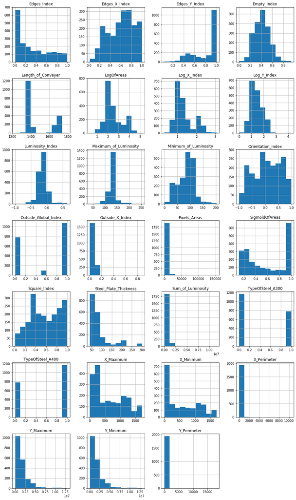

```python
# Histograms for each attribute
X_original.hist(layout=(dispRow,dispCol))
plt.show()
```

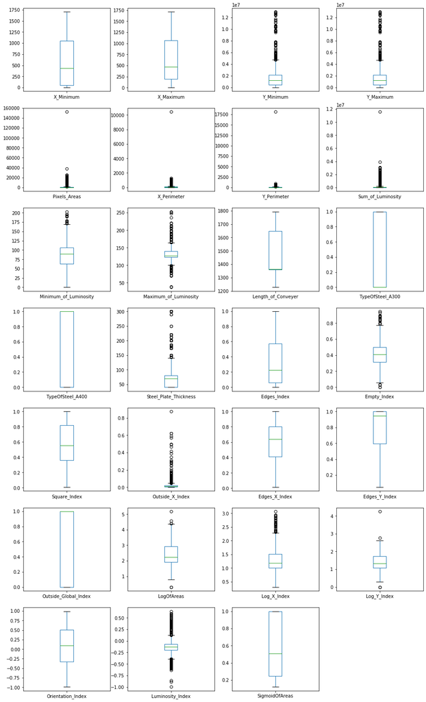

```python
# Box and Whisker plot for each attribute
X_original.plot(kind='box', subplots=True, layout=(dispRow,dispCol))
plt.show()
```

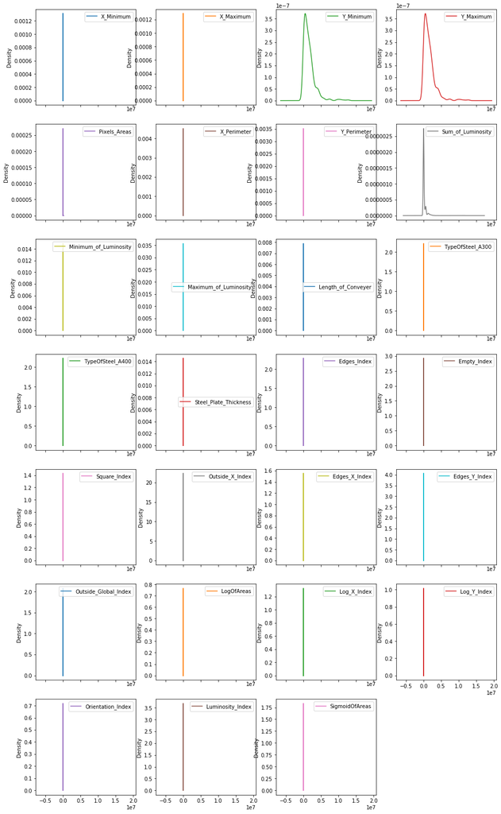

```python
# Density plot for each attribute
X_original.plot(kind='density', subplots=True, layout=(dispRow,dispCol))
plt.show()
```

#### 2.b.ii) Multivariate plots to better understand the relationships between attributes

```python
# Scatterplot matrix
# scatter_matrix(X_original)
# plt.show()
```

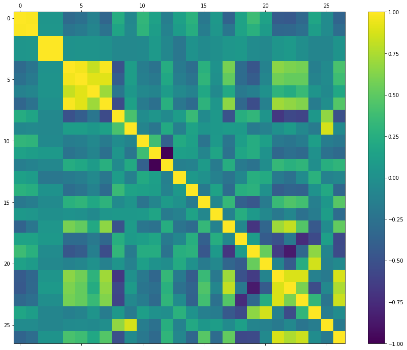

```python
# Correlation matrix
fig = plt.figure(figsize=(16,12))
ax = fig.add_subplot(111)
correlations = X_original.corr(method='pearson')
cax = ax.matshow(correlations, vmin=-1, vmax=1)
fig.colorbar(cax)
plt.show()
```

```python
if (notifyStatus): email_notify("Data Summarization and Visualization completed! "+datetime.now().strftime('%a %B %d, %Y %I:%M:%S %p'))
```

## Section 3 - Prepare Data

Some dataset may require additional preparation activities that will best exposes the structure of the problem and the relationships between the input attributes and the output variable. Some data-prep tasks might include:

- Cleaning data by removing duplicates, marking missing values and even imputing missing values.
- Feature selection where redundant features may be removed.
- Data transforms where attributes are scaled or redistributed in order to best expose the structure of the problem later to learning algorithms.

```python
if (notifyStatus): email_notify("Data Cleaning and Transformation has begun! "+datetime.now().strftime('%a %B %d, %Y %I:%M:%S %p'))
```

### 3.a) Feature Scaling and Data Pre-Processing

```python
# Apply feature scaling techniques
X_original = X_original.astype(float)
preprocessing.scale(X_original, copy=False)
print(X_original.head(-10))
```

```
      X_Minimum  X_Maximum  Y_Minimum  Y_Maximum  Pixels_Areas  X_Perimeter  \
0     -1.016481  -1.141639  -0.777729  -0.777729     -0.314852    -0.314996
1      0.141894   0.066403   0.500188   0.500171     -0.345623    -0.338242
2      0.495362   0.436253  -0.054546  -0.054566     -0.352784    -0.344883
3      0.541467   0.486504  -0.722225  -0.722225     -0.332463    -0.328279
4      1.379032   1.382988  -0.649678  -0.649559      0.099692    -0.172201
...         ...        ...        ...        ...           ...          ...
1926   0.925671   0.894545  -0.832794  -0.832808     -0.353364    -0.285109
1927  -0.789801  -0.900432  -0.787854  -0.787867     -0.347752    -0.291750
1928   1.405926   1.459370  -0.911655  -0.911665     -0.279048    -0.225334
1929  -0.847432  -0.934603  -0.818988  -0.819003     -0.320077    -0.215372
1930  -0.622672  -0.695407  -0.792864  -0.792878     -0.321045    -0.251901

      Y_Perimeter  Sum_of_Luminosity  Minimum_of_Luminosity  \
0       -0.091389          -0.355537              -0.266099
```

[output cut: 51 more lines]

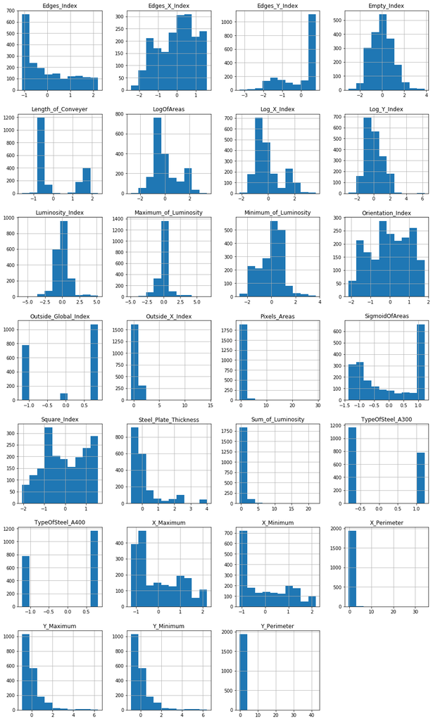

```python
# Histograms for each attribute
X_original.hist(layout=(dispRow,dispCol))
plt.show()
```

### 3.b) Splitting Data into Training and Test Sets

```python
# Split the data further into training and test datasets
if (splitDataset):
    X_train_df, X_test_df, y_train_df, y_test_df = train_test_split(X_original, y_original, test_size=splitPercentage,
                                                                    stratify=y_original, random_state=seedNum)
else:
    X_train_df, y_train_df = X_original, y_original
    X_test_df, y_test_df = X_original, y_original
print("X_train.shape: {} y_train_df.shape: {}".format(X_train_df.shape, y_train_df.shape))
print("X_test_df.shape: {} y_test_df.shape: {}".format(X_test_df.shape, y_test_df.shape))
```

```
X_train.shape: (1455, 27) y_train_df.shape: (1455,)
X_test_df.shape: (486, 27) y_test_df.shape: (486,)
```

### 3.c) Feature Selection

```python
# Not applicable for this iteration of the project
```

### 3.d) Display the Final Datasets for Model-Building

```python
# Finalize the training and testing datasets for the modeling activities
X_train = X_train_df.to_numpy()
y_train = y_train_df.to_numpy()
X_test = X_test_df.to_numpy()
y_test = y_test_df.to_numpy()
print("X_train.shape: {} y_train.shape: {}".format(X_train.shape, y_train.shape))
print("X_test.shape: {} y_test.shape: {}".format(X_test.shape, y_test.shape))
```

```
X_train.shape: (1455, 27) y_train.shape: (1455,)
X_test.shape: (486, 27) y_test.shape: (486,)
```

```python
if (notifyStatus): email_notify("Data Cleaning and Transformation completed! "+datetime.now().strftime('%a %B %d, %Y %I:%M:%S %p'))
```

## 4. Model and Evaluate Algorithms

After the data-prep, we next work on finding a workable model by evaluating a subset of machine learning algorithms that are good at exploiting the structure of the training. The typical evaluation tasks include:

- Defining test options such as cross validation and the evaluation metric to use.
- Spot checking a suite of linear and nonlinear machine learning algorithms.
- Comparing the estimated accuracy of algorithms.

Linear Algorithm: Linear Discriminant Analysis

Non-Linear Algorithms: Decision Trees (CART) and k-Nearest Neighbors

Ensemble Algorithms: Bagged Decision Trees, Random Forest, Extra Trees, and Gradient Boosting

The random number seed is reset before each run to ensure that the evaluation of each algorithm is performed using the same data splits. It ensures the results are directly comparable.

### 4.a) Set test options and evaluation metric

```python
# Set up Algorithms Spot-Checking Array
startTimeModule = datetime.now()
train_models = []
train_results = []
train_model_names = []
train_metrics = []
train_models.append(('LDA', LinearDiscriminantAnalysis()))
train_models.append(('CART', DecisionTreeClassifier(random_state=seedNum)))
train_models.append(('KNN', KNeighborsClassifier(n_jobs=n_jobs)))
train_models.append(('BT', BaggingClassifier(random_state=seedNum, n_jobs=n_jobs)))
train_models.append(('RF', RandomForestClassifier(random_state=seedNum, n_jobs=n_jobs)))
train_models.append(('ET', ExtraTreesClassifier(random_state=seedNum, n_jobs=n_jobs)))
train_models.append(('GBM', GradientBoostingClassifier(random_state=seedNum)))
# models.append(('XGB', XGBClassifier(random_state=seedNum, n_jobs=n_jobs)))
```

```python
# Generate model in turn
for name, model in train_models:
	if (notifyStatus): email_notify("Algorithm "+name+" modeling has begun! "+datetime.now().strftime('%a %B %d, %Y %I:%M:%S %p'))
	startTimeModule = datetime.now()
	kfold = KFold(n_splits=n_folds, random_state=seedNum)
	cv_results = cross_val_score(model, X_train, y_train, cv=kfold, scoring=scoring)
	train_results.append(cv_results)
	train_model_names.append(name)
	train_metrics.append(cv_results.mean())
	print("%s: %f (%f)" % (name, cv_results.mean(), cv_results.std()))
	print(model)
	print ('Model training time:', (datetime.now() - startTimeModule), '\n')
	if (notifyStatus): email_notify("Algorithm "+name+" modeling completed! "+datetime.now().strftime('%a %B %d, %Y %I:%M:%S %p'))
print ('Average metrics ('+scoring+') from all models:',np.mean(train_metrics))
print ('Total training time for all models:',(datetime.now() - startTimeModule))
```

```
LDA: 0.683769 (0.043110)
LinearDiscriminantAnalysis(n_components=None, priors=None, shrinkage=None,
                           solver='svd', store_covariance=False, tol=0.0001)
Model training time: 0:00:00.507355

CART: 0.716854 (0.036888)
DecisionTreeClassifier(class_weight=None, criterion='gini', max_depth=None,
                       max_features=None, max_leaf_nodes=None,
                       min_impurity_decrease=0.0, min_impurity_split=None,
                       min_samples_leaf=1, min_samples_split=2,
                       min_weight_fraction_leaf=0.0, presort=False,
                       random_state=888, splitter='best')
Model training time: 0:00:00.675085

KNN: 0.737411 (0.040672)
KNeighborsClassifier(algorithm='auto', leaf_size=30, metric='minkowski',
                     metric_params=None, n_jobs=-1, n_neighbors=5, p=2,
                     weights='uniform')
Model training time: 0:00:32.107325

BT: 0.761530 (0.030993)
BaggingClassifier(base_estimator=None, bootstrap=True, bootstrap_features=False,
                  max_features=1.0, max_samples=1.0, n_estimators=10, n_jobs=-1,
                  oob_score=False, random_state=888, verbose=0,
                  warm_start=False)
Model training time: 0:00:54.968563

RF: 0.738819 (0.034528)
RandomForestClassifier(bootstrap=True, class_weight=None, criterion='gini',
                       max_depth=None, max_features='auto', max_leaf_nodes=None,
                       min_impurity_decrease=0.0, min_impurity_split=None,
                       min_samples_leaf=1, min_samples_split=2,
                       min_weight_fraction_leaf=0.0, n_estimators='warn',
                       n_jobs=-1, oob_score=False, random_state=888, verbose=0,
                       warm_start=False)
Model training time: 0:00:32.198838

ET: 0.753236 (0.030160)
ExtraTreesClassifier(bootstrap=False, class_weight=None, criterion='gini',
                     max_depth=None, max_features='auto', max_leaf_nodes=None,
                     min_impurity_decrease=0.0, min_impurity_split=None,
                     min_samples_leaf=1, min_samples_split=2,
                     min_weight_fraction_leaf=0.0, n_estimators='warn',
                     n_jobs=-1, oob_score=False, random_state=888, verbose=0,
                     warm_start=False)
Model training time: 0:00:31.407304

GBM: 0.788271 (0.039860)
GradientBoostingClassifier(criterion='friedman_mse', init=None,
                           learning_rate=0.1, loss='deviance', max_depth=3,
                           max_features=None, max_leaf_nodes=None,
                           min_impurity_decrease=0.0, min_impurity_split=None,
                           min_samples_leaf=1, min_samples_split=2,
                           min_weight_fraction_leaf=0.0, n_estimators=100,
                           n_iter_no_change=None, presort='auto',
                           random_state=888, subsample=1.0, tol=0.0001,
                           validation_fraction=0.1, verbose=0,
                           warm_start=False)
Model training time: 0:01:13.037748

Average metrics (accuracy) from all models: 0.7399844793845739
Total training time for all models: 0:01:13.039170
```

### 4.b) Spot-checking baseline algorithms

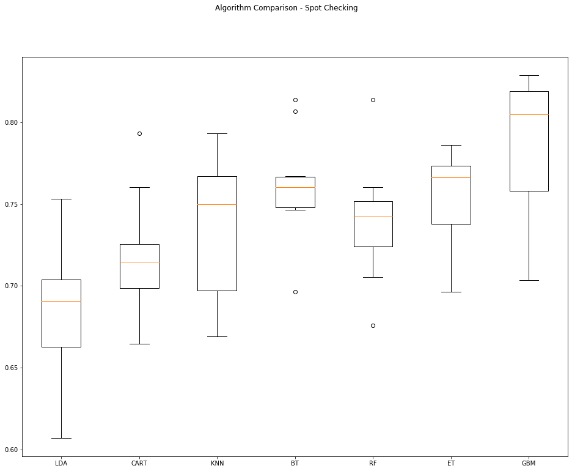

```python
fig = plt.figure(figsize=(16,12))
fig.suptitle('Algorithm Comparison - Spot Checking')
ax = fig.add_subplot(111)
plt.boxplot(train_results)
ax.set_xticklabels(train_model_names)
plt.show()
```

## Section 5 - Improve Accuracy

After we achieve a short list of machine learning algorithms with good level of accuracy, we can leverage ways to improve the accuracy of the models.

### 5.a) Algorithm Tuning

```python
# Set up the comparison array
tune_results = []
tune_names = []
```

```python
# Tuning algorithm #1 - Bagged Decision Trees
startTimeModule = datetime.now()
if (notifyStatus): email_notify("Algorithm #1 tuning has begun! "+datetime.now().strftime('%a %B %d, %Y %I:%M:%S %p'))

tune_model1 = BaggingClassifier(random_state=seedNum, n_jobs=n_jobs)
tune_names.append('BDT')
paramGrid1 = dict(n_estimators=np.array([50, 100, 150, 200, 250]))

kfold = KFold(n_splits=n_folds, random_state=seedNum)
grid1 = GridSearchCV(estimator=tune_model1, param_grid=paramGrid1, scoring=scoring, cv=kfold)
grid_result1 = grid1.fit(X_train, y_train)

print("Best: %f using %s" % (grid_result1.best_score_, grid_result1.best_params_))
tune_results.append(grid_result1.cv_results_['mean_test_score'])
means = grid_result1.cv_results_['mean_test_score']
stds = grid_result1.cv_results_['std_test_score']
params = grid_result1.cv_results_['params']
for mean, stdev, param in zip(means, stds, params):
    print("%f (%f) with: %r" % (mean, stdev, param))
print ('Model training time:',(datetime.now() - startTimeModule))
if (notifyStatus): email_notify("Algorithm #1 tuning completed! "+datetime.now().strftime('%a %B %d, %Y %I:%M:%S %p'))
```

```
Best: 0.787629 using {'n_estimators': 150}
0.772509 (0.037693) with: {'n_estimators': 50}
0.783505 (0.032104) with: {'n_estimators': 100}
0.787629 (0.037030) with: {'n_estimators': 150}
0.784880 (0.032697) with: {'n_estimators': 200}
0.784192 (0.030575) with: {'n_estimators': 250}
Model training time: 0:05:51.975828
```

```python
for key, value in grid_result1.best_params_.items():
    best_paramKey1 = key
    best_paramValue1 = value
print("Captured the best parameter for algorithm #1:", best_paramKey1, '=', best_paramValue1)
```

```
Captured the best parameter for algorithm #1: n_estimators = 150
```

```python
# Tuning algorithm #2 - Gradient Boosting
startTimeModule = datetime.now()
if (notifyStatus): email_notify("Algorithm #2 tuning has begun! "+datetime.now().strftime('%a %B %d, %Y %I:%M:%S %p'))

tune_model2 = GradientBoostingClassifier(random_state=seedNum)
tune_names.append('GBM')
paramGrid2 = dict(n_estimators=np.array([100, 150, 200, 250, 300]))

kfold = KFold(n_splits=n_folds, random_state=seedNum)
grid2 = GridSearchCV(estimator=tune_model2, param_grid=paramGrid2, scoring=scoring, cv=kfold)
grid_result2 = grid2.fit(X_train, y_train)

print("Best: %f using %s" % (grid_result2.best_score_, grid_result2.best_params_))
tune_results.append(grid_result2.cv_results_['mean_test_score'])
means = grid_result2.cv_results_['mean_test_score']
stds = grid_result2.cv_results_['std_test_score']
params = grid_result2.cv_results_['params']
for mean, stdev, param in zip(means, stds, params):
    print("%f (%f) with: %r" % (mean, stdev, param))
print ('Model training time:',(datetime.now() - startTimeModule))
if (notifyStatus): email_notify("Algorithm #2 tuning completed! "+datetime.now().strftime('%a %B %d, %Y %I:%M:%S %p'))
```

```
Best: 0.793127 using {'n_estimators': 150}
0.788316 (0.039835) with: {'n_estimators': 100}
0.793127 (0.036995) with: {'n_estimators': 150}
0.793127 (0.035663) with: {'n_estimators': 200}
0.786942 (0.037781) with: {'n_estimators': 250}
0.789691 (0.039773) with: {'n_estimators': 300}
Model training time: 0:11:24.731314
```

```python
for key, value in grid_result2.best_params_.items():
    best_paramKey2 = key
    best_paramValue2 = value
print("Captured the best parameter for algorithm #2:", best_paramKey2, '=', best_paramValue2)
```

```
Captured the best parameter for algorithm #2: n_estimators = 150
```

### 5.b) Compare Algorithms After Tuning

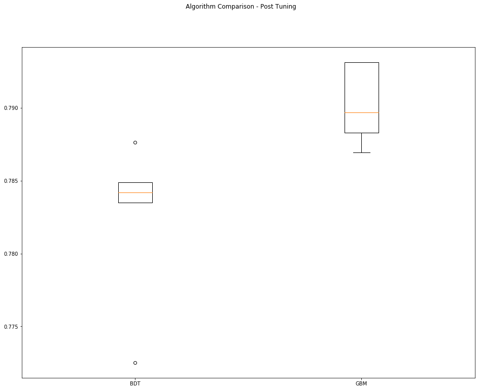

```python
fig = plt.figure(figsize=(16,12))
fig.suptitle('Algorithm Comparison - Post Tuning')
ax = fig.add_subplot(111)
plt.boxplot(tune_results)
ax.set_xticklabels(tune_names)
plt.show()
```

## Section 6 - Finalize Model

Once we have narrow down to a model that we believe can make accurate predictions on unseen data, we are ready to finalize it. Finalizing a model may involve sub-tasks such as:

- Using an optimal model tuned to make predictions on unseen data.
- Creating a standalone model using the tuned parameters
- Saving an optimal model to file for later use.

```python
if (notifyStatus): email_notify("Model Validation and Final Model Creation has begun! "+datetime.now().strftime('%a %B %d, %Y %I:%M:%S %p'))
```

### 6.a) Measure predictions from the test dataset

```python
test_model1 = BaggingClassifier(n_estimators=best_paramValue1, random_state=seedNum, n_jobs=n_jobs)
test_model1.fit(X_train, y_train)
predictions1 = test_model1.predict(X_test)
print('Accuracy Score:', accuracy_score(y_test, predictions1))
print(confusion_matrix(y_test, predictions1))
print(classification_report(y_test, predictions1))
print(test_model1)
```

```
Accuracy Score: 0.7880658436213992
[[ 69   1   0  23   6   0   2]
 [  0  12   0   2   0   0   0]
 [  1   0  94   3   0   0   0]
 [ 25   1   3 132   5   2   0]
 [  7   1   0  12  19   0   0]
 [  0   0   0   3   0  15   0]
 [  0   0   0   6   0   0  42]]
              precision    recall  f1-score   support

       Bumps       0.68      0.68      0.68       101
   Dirtiness       0.80      0.86      0.83        14
    K_Scatch       0.97      0.96      0.96        98
Other_Faults       0.73      0.79      0.76       168
      Pastry       0.63      0.49      0.55        39
      Stains       0.88      0.83      0.86        18
   Z_Scratch       0.95      0.88      0.91        48

    accuracy                           0.79       486
   macro avg       0.81      0.78      0.79       486
weighted avg       0.79      0.79      0.79       486

BaggingClassifier(base_estimator=None, bootstrap=True, bootstrap_features=False,
                  max_features=1.0, max_samples=1.0, n_estimators=150,
                  n_jobs=-1, oob_score=False, random_state=888, verbose=0,
                  warm_start=False)
```

```python
test_model2 = GradientBoostingClassifier(n_estimators=best_paramValue2, random_state=seedNum)
test_model2.fit(X_train, y_train)
predictions2 = test_model2.predict(X_test)
print('Accuracy Score:', accuracy_score(y_test, predictions2))
print(confusion_matrix(y_test, predictions2))
print(classification_report(y_test, predictions2))
print(test_model2)
```

```
Accuracy Score: 0.7880658436213992
[[ 69   0   0  24   7   0   1]
 [  0  10   0   3   1   0   0]
 [  0   0  93   5   0   0   0]
 [ 23   1   4 130   7   1   2]
 [  7   0   0  11  21   0   0]
 [  0   0   0   3   0  15   0]
 [  0   0   0   3   0   0  45]]
              precision    recall  f1-score   support

       Bumps       0.70      0.68      0.69       101
   Dirtiness       0.91      0.71      0.80        14
    K_Scatch       0.96      0.95      0.95        98
Other_Faults       0.73      0.77      0.75       168
      Pastry       0.58      0.54      0.56        39
      Stains       0.94      0.83      0.88        18
   Z_Scratch       0.94      0.94      0.94        48

    accuracy                           0.79       486
   macro avg       0.82      0.78      0.80       486
weighted avg       0.79      0.79      0.79       486

GradientBoostingClassifier(criterion='friedman_mse', init=None,
                           learning_rate=0.1, loss='deviance', max_depth=3,
                           max_features=None, max_leaf_nodes=None,
                           min_impurity_decrease=0.0, min_impurity_split=None,
                           min_samples_leaf=1, min_samples_split=2,
                           min_weight_fraction_leaf=0.0, n_estimators=150,
                           n_iter_no_change=None, presort='auto',
                           random_state=888, subsample=1.0, tol=0.0001,
                           validation_fraction=0.1, verbose=0,
                           warm_start=False)
```

### 6.b) Create a standalone model using all available data

```python
# Combining the training and testing datasets to form the complete dataset that will be used for training the final model
X_complete = np.vstack((X_train, X_test))
y_complete = np.concatenate((y_train, y_test))
print("X_complete.shape: {} y_complete.shape: {}".format(X_complete.shape, y_complete.shape))
finalModel = test_model2
```

```
X_complete.shape: (1941, 27) y_complete.shape: (1941,)
```

### 6.c) Save the final model for later use

```python
# modelName = 'finalModel_MultiClass.sav'
# dump(finalModel, modelName)
```

```python
if (notifyStatus): email_notify("Model Validation and Final Model Creation completed! "+datetime.now().strftime('%a %B %d, %Y %I:%M:%S %p'))
```

```python
print ('Total time for the script:',(datetime.now() - startTimeScript))
```

```
Total time for the script: 0:22:28.422909
```